# Intro to ggplot and tidy data

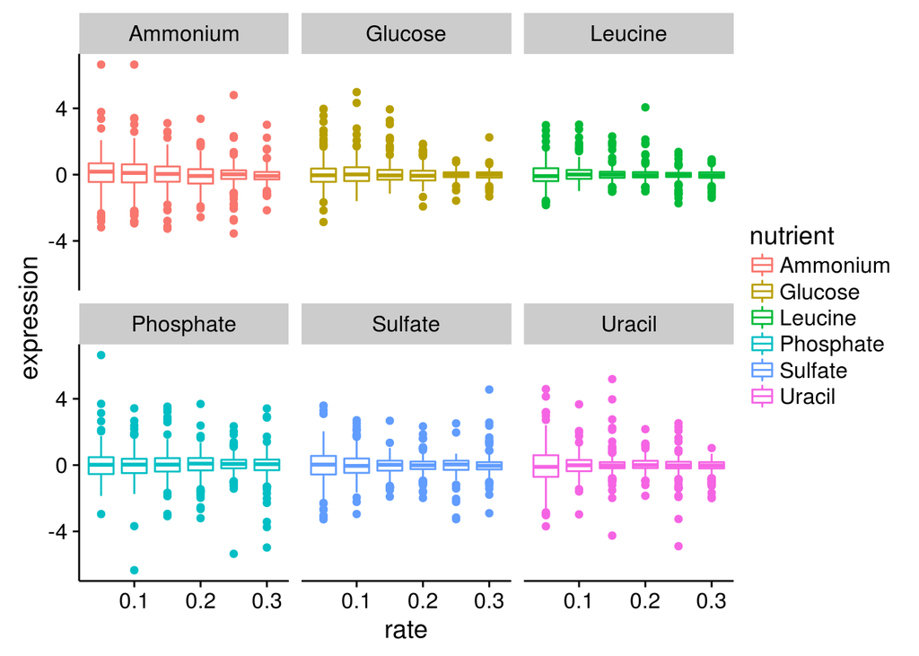

```r
ggplot(data=miniyeast, aes(x=rate, y=expression, group=rate, color=nutrient)) +
   geom_boxplot() +
   facet_wrap(~nutrient)
```

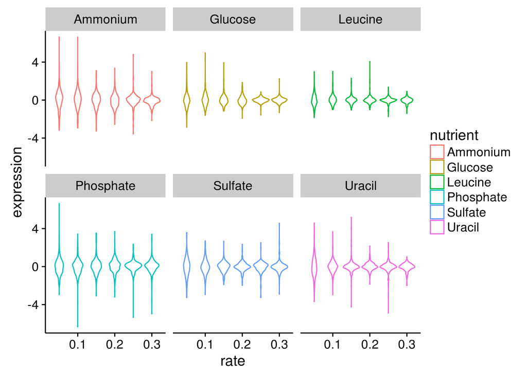

```r
ggplot(data=miniyeast, aes(x=rate, y=expression, group=rate, color=nutrient)) +
   geom_violin() +
   facet_wrap(~nutrient)
```

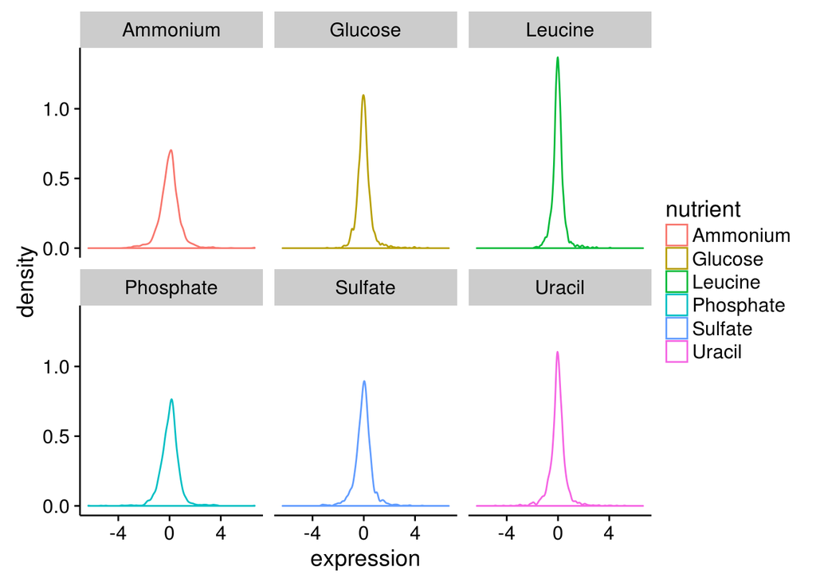

```r
ggplot(data=miniyeast, aes(expression, color=nutrient)) +
   geom_density() +
   facet_wrap(~nutrient)
```

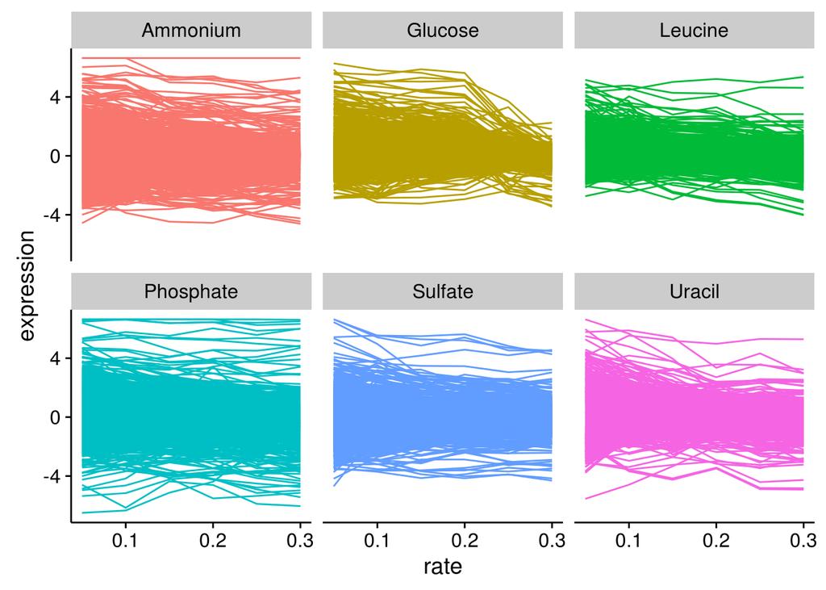

```r
#Take a look at all the the data together
#Takes longer to plot, but isn't unreasonable
ggplot(data=yeast, aes(x=rate, y= expression, group=gene, color=nutrient)) +
   geom_line() +
   theme(legend.position="none") +  #We don't want a giant legend with each gene name
   facet_wrap(~nutrient)
```

#### Doing an analysis and visualizing the results

- I saw that there are tracks which have positive and negative slopes in all the nutrients
- I decided to look for genes which are up in some conditions and down in others using the dplyr functions from last week
- I take the pearson correlations of rate vs. expression for each gene:nutrient pair
- I then take the genes which have high variance between their pearson correlations for the different nutrients

```r
yeast %>%
   group_by(gene, nutrient) %>%
   dplyr::summarise(Pearson = cor(rate,expression)) %>% #make a new column called "Pearson" with the correlation btw rate and expression
   group_by(gene) %>%                                   #Regroup by gene
   dplyr::summarize(variance = var(Pearson)) %>%        #Take the variance of each genes correlations in the different nutrients
   filter(variance > 0.75) -> variable_gene_list        #Save genes with high variance

print(variable_gene_list)
```

```
## # A tibble: 14 × 2
##     gene  variance
##    <chr>     <dbl>
## 1   ACO1 0.7772702
## 2   ALD5 0.7625211
## 3   ARO3 0.8150971
## 4   DIC1 0.7582985
## 5  ECM40 0.8293947
## 6   ICS2 0.7512776
## 7   ISU2 0.7681774
## 8   KTR7 0.7815662
## 9   MTM1 0.7797293
## 10  SAM3 0.8017918
## 11  TMT1 0.7791315
## 12  TRP3 0.7516171
## 13  VHT1 0.8796082
## 14  ZPS1 0.7840669
```

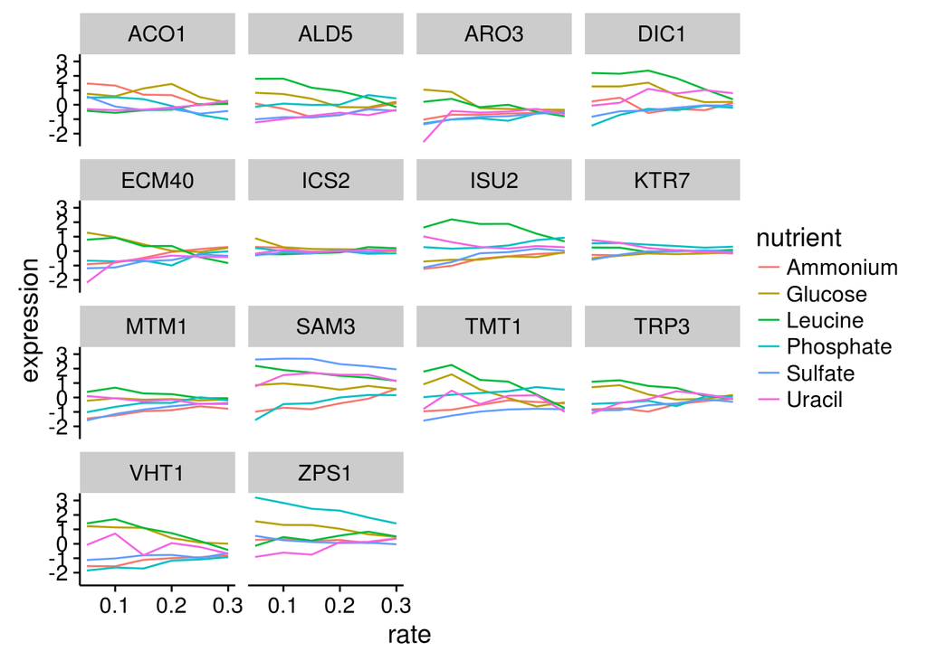

```r
# Pull the data from the full dataset for the set of genes with high variance
variable_data <- yeast %>% filter(gene %in% variable_gene_list$gene)

ggplot(data=variable_data  , aes(x=rate, y=expression, group=nutrient, color=nutrient)) +
    geom_line() +
    facet_wrap(~gene)
```

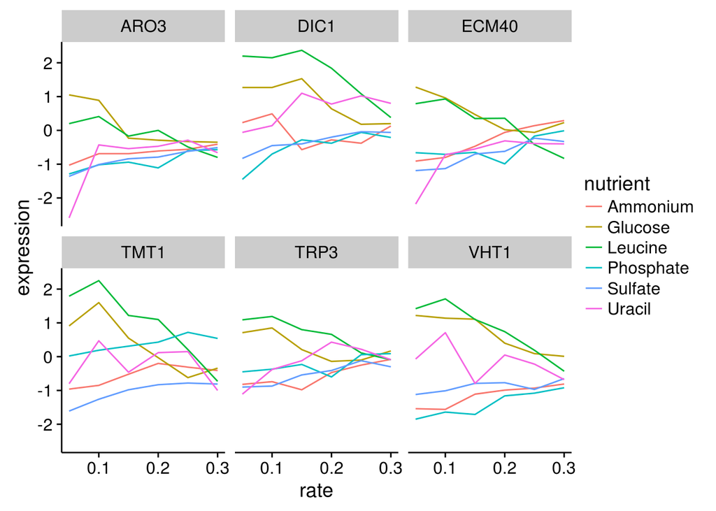

```r
# I noticed that there is a set of genes which are down in glucose/leucine and up in the other conditions
# Let's pull just those out to make a figure
selected_genes <- yeast %>% filter(gene %in%  c("ARO3", "DIC1", "ECM40", "TMT1", "TRP3", "VHT1"))

ggplot(data=selected_genes , aes(x=rate, y=expression, group=nutrient, color=nutrient)) +
    geom_line() +
    facet_wrap(~gene)
```

### Make it look nice

Getting the data accurately displayed is just the first step of plotting

The default plot always needs to be cleaned up for publication/presentation

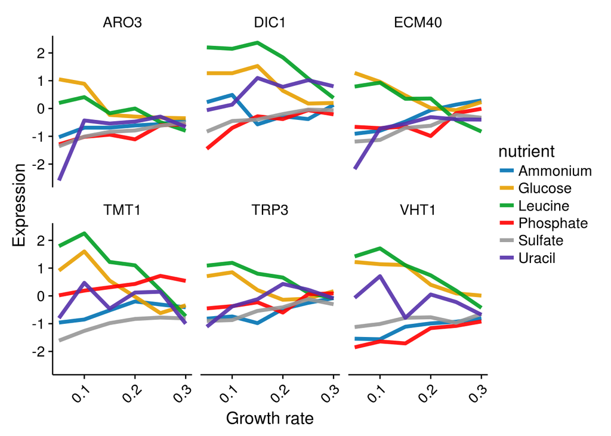

```r
#custom palette
palette <- c("#0072B2","#E69F00","#009E24","#FF0000", "#979797","#5530AA")

#loading cowplot increases text size and removes the default grey background
#It is also really useful for more advanced plotting later on

#Here, I'm adding and silencing features I want fir the final plot
#I find plot features by googling something to the tune of:
#      change line thickness geom_line ggplot
#      ggplot use custom color palette

pairs_plt <- ggplot(data=selected_genes , aes(x=rate, y=expression, group=nutrient, color=nutrient)) +
     geom_line(size=1.5, alpha=0.9) +                                 # Thicker lines, and slightly transparent
     facet_wrap(~gene) +                                              # Each gene gets a plot
     theme(strip.background=element_blank()) +                        # I don't want the grey box around the gene IDs
     theme(axis.text.x=element_text(angle=45, vjust =1, hjust = 1)) + # I want the x axis labels at at 45 degree angle
     ylab("Expression") +                                             # New y label
     xlab("Growth rate") +                                            # New x label
     scale_color_manual(values=palette)                               # Use custom colors

pairs_plt
```

### An aside about colors and plotting

This plot uses a palette of colors I prefer over the default

Default ggplot pastels are *not* colorblind accessible

- Go for bold, saturated colors, avoid pastels and anything dull/washed-out
- Use thick lines, particularly in powerpoint presentations
- Try to use redundant encoding for conditions (like shapes, dashed vs. solid etc.)
- Avoid non-intuitive problematic color pairings like:

  ```
   teal/white

   lightpink/grey

   red/black

   darkblue/purple

   dull green/dull orange
  ```

- Do not use thin red and black lines or small red/black dots to represent different data conditions
- Make heatmaps blue/yellow, NOT red/green

### Another plot

#### And a dire warning about using bar charts

```r
# Picking genes that have are really high pearson correlations between rate and expression in at least one conditions

yeast %>%
  group_by(gene, nutrient) %>%
  dplyr::summarise(Pearson = cor(as.numeric(rate),expression)) %>%
  filter (Pearson < -0.99) %>%
  tail(50) -> negcor_genes

print(negcor_genes)
```

```
## Source: local data frame [50 x 3]
## Groups: gene [46]
##
##     gene  nutrient    Pearson
##    <chr>     <chr>      <dbl>
## 1  PEX22 Phosphate -0.9933471
## 2  PFK26    Uracil -0.9958449
## 3   PMA1  Ammonium -0.9908281
## 4   POT1   Sulfate -0.9929707
## 5   POX1   Sulfate -0.9913513
## 6   PRM2 Phosphate -0.9919375
## 7   PRX1 Phosphate -0.9980598
## 8   PSK2  Ammonium -0.9929896
## 9   RAD4  Ammonium -0.9957523
## 10  RIB1   Glucose -0.9900264
## # ... with 40 more rows
```

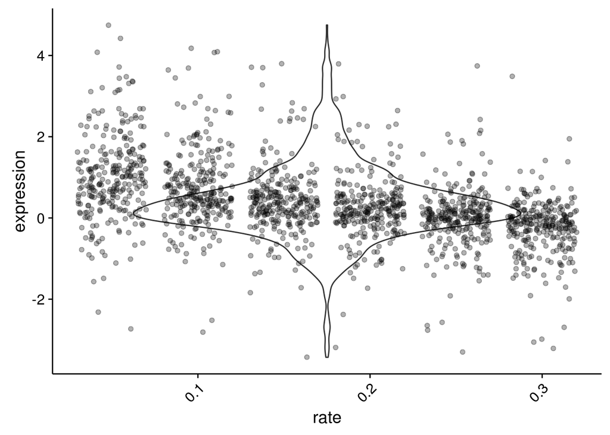

```r
#Selecting the genes I found with high position correlation from the full dataset
negcor <- yeast %>%
     filter(gene %in% negcor_genes$gene)

negplt <- ggplot(data=negcor , aes(x=rate, y=expression)) +
     geom_violin() +
     geom_jitter(alpha=0.3)+
     theme(axis.text.x=element_text(angle=45, vjust =1, hjust = 1)) +
     scale_color_manual(values=palette)
negplt
```

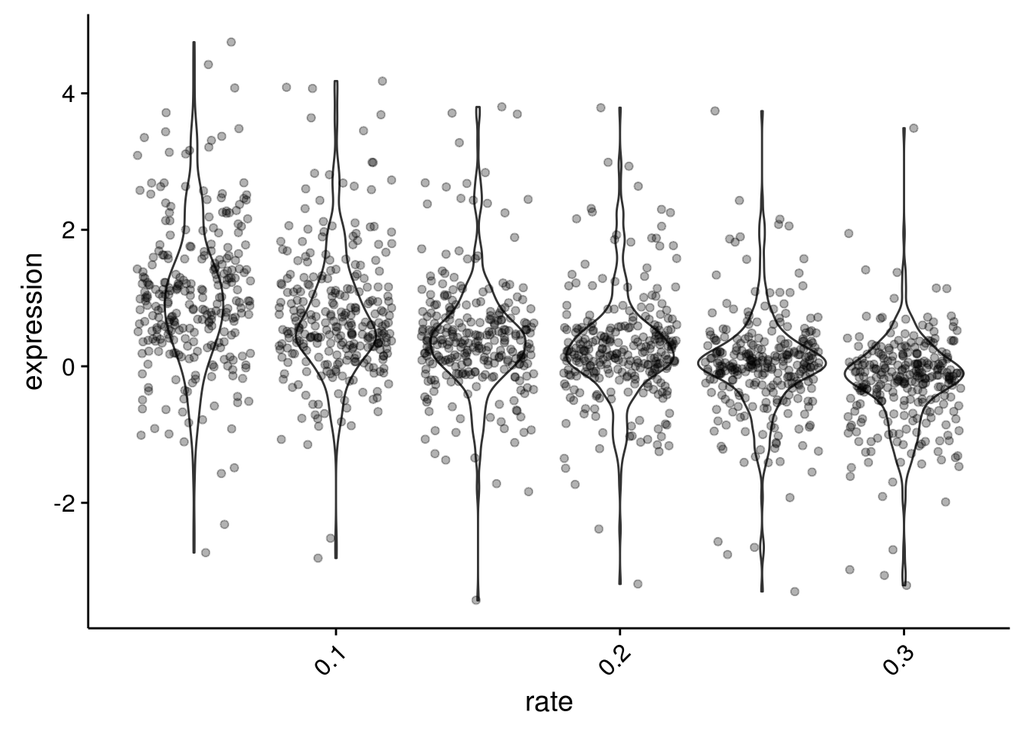

```r
# Aes can be assigned to individual plots
negplt <- ggplot(data=negcor , aes(x=rate, y=expression)) +
     geom_violin(aes(group=rate)) +
     geom_jitter(alpha=0.3)+
     theme(axis.text.x=element_text(angle=45, vjust =1, hjust = 1)) +
     scale_color_manual(values=palette)

negplt
```

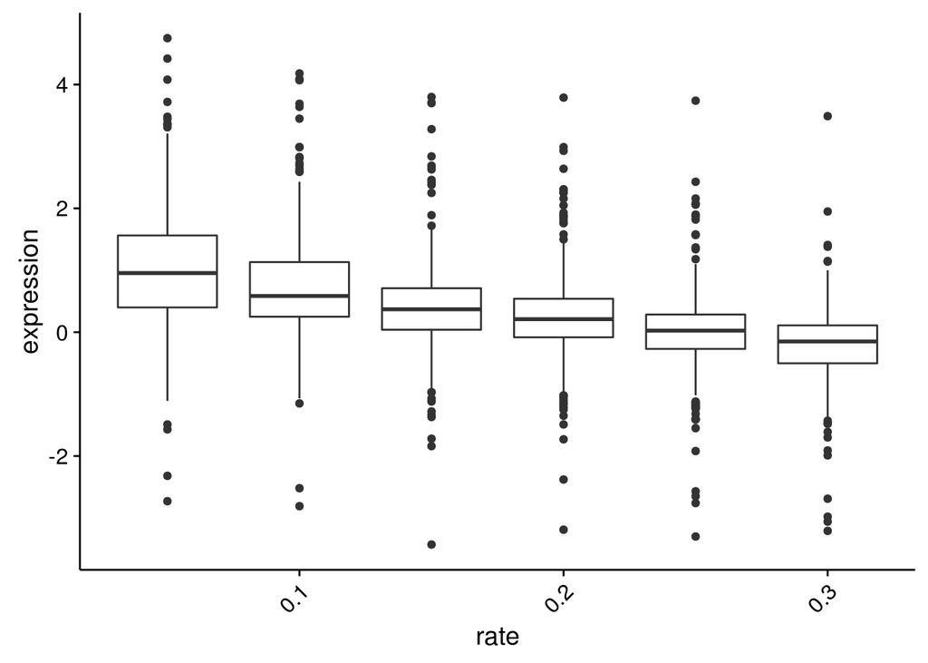

```r
#Boxplot version
negplt_box <- ggplot(data=negcor , aes(x=rate, y=expression, group=rate)) +
     geom_boxplot(alpha=0.3)+
     theme(axis.text.x=element_text(angle=45, vjust =1, hjust = 1)) +
     scale_color_manual(values=palette)

negplt_box
```

### Plotting the exact same data as above as a bar plot

There are definitely times when bar plots are appropriate

And then there’s most other times

Bar plots hide the underlying distribution of observations in data

- Many papers represent data as bar plot + standard error of the mean (SEM)
- Standard error is almost never the appropriate statistic, but people use it because it is small and makes plots look more impressive
- Standard error of the means tells almost nothing about the underlying distribution of the data
- Choosing a plot format because it hides something troubling in the data => unethical
- If a violin, jitter, or box plot can be used, it’s almost 100% the preferable way to present the data
- Once you start to look for bar plots +/- SEM in papers, you find them everywhere

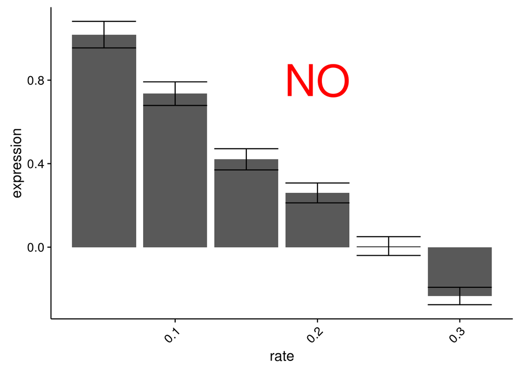

```r
# Don't make plots like this
# Don't use standard error of the mean to hide variation
negplt_mean<- ggplot(data=negcor , aes(x=rate, y=expression)) +
     geom_bar(stat="summary", fun.y="mean") +
     stat_summary(fun.data = mean_se, geom = "errorbar") +
     theme(axis.text.x=element_text(angle=45, vjust =1, hjust = 1)) +
     scale_color_manual(values=palette) +
     annotate ("text", x = 0.2, y=0.8, label="NO", color="red", size=15)

negplt_mean
```

```r
# This is not an accurate representation of the data compared to the previous two charts
```

### Assembling and saving a figure

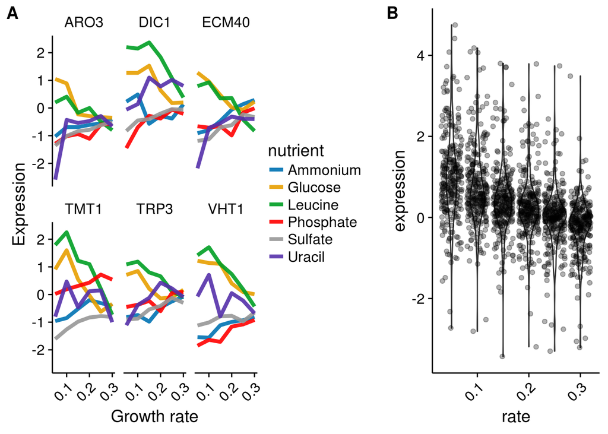

```r
final_figure <- plot_grid(pairs_plt, negplt, labels = c("A", "B"), ncol = 2, rel_widths = c(1,0.6))

final_figure
```

```r
ggsave(plot = final_figure, file = "Figure1.pdf", device= "pdf", width=7, height=5, units="in")
```